# Text as Linguistic Data

Korpusanalyse mit polmineR

Andreas Blaette

16 April 2018

## Warum Korpusanalyse mit R?

- R als sozialwissenschaftliche ‘lingua franca’
- Interaktivität
- freundliche Nutzercommunity
- RStudio als IDE
- dynamische Weiterentwicklung von R, RStudio

## Zielsetzungen von polmineR

- Quelloffenheit (Open Source)
- Portabilität (Nutzung unter Windows, macOS, Linux)
- Interaktivität
- Reproduzierbarkeit und Validität (durch Volltextanzeigen)
- Performanz
- Nutzerfreundlichkeit (Dokumentation)

## Installation

### Systemvoraussetzungen

- Windows, macOS, Linux
- (möglichst) mehr als 4GB Arbeitsspeicher
- optional: mehrere Prozessorkerne, SSD

### Installation von polmineR: Windows

#### Installation des CRAN-Relase

```r
install.packages("polmineR.Rcpp", repos = "http://polmine.sowi.uni-due.de/packages", type = "win.binary")
install.packages("polmineR")
```

#### Installation der Entwicklungsversion auf GitHub

```r
devtools::install_github("PolMine/polmineR", ref = "dev")
```

## Schritte nach der Installation

```r
library(polmineR)
```

### Umgebungsvariable CORPUS_REGISTRY

Die Umgebungsvariable ‘CORPUS_REGISTRY’ kann folgendermaßen vorübergehend gesetzt werden.

```r
Sys.getenv("CORPUS_REGISTRY")
Sys.setenv(CORPUS_REGISTRY="/var/local/cwb/registry")
```

Die dauerhafte Definition ist möglich über folgende Dateien: - .Renviron - Startup-Dateien in /etc/R/

### Installation von Korpora

Über den PolMine-Webserver steht das GermaParl-Korpus zur Verfügung.

```r
library(polmineR)
install.corpus("GermaParl")
```

Aktivierung eines Korpus in einem R-Datenpaket:

```r
use("GermaParl")
```

### polmineR - Schnelleinstieg (Arbeit mit Korpora und CQP)

Anzeige von Konkordanzen / Keyword-in-Context (KWIC) …

```r
kwic("GERMAPARL", "Islam", meta = "year")
kwic("GERMAPARL", '[pos = "ADJA"] "Integration"', cqp = TRUE, meta = "speaker")
```

Zählung von Worthäufigkeiten …

```r
cnt <- count("GERMAPARL", pAttribute = "word")
```

Arbeit mit komplexen Suchbegriffen (CQP Syntax)

```r
count("GERMAPARL", query = '[pos = "ADJA"] "Integration"')
```

Verteilung eines Suchbegriffs …

```r
d <- dispersion("GERMAPARL", query = "Aussiedler", sAttribute = "year")
```

### polmineR - Schnelleinstieg (Arbeit mit Subkorpora / “Partitionen”)

Anlegen einer Partition …

```r
merkel <- partition("GERMAPARL", speaker = "Angela Merkel", date = "2005-11-30", type = "plpr")
```

Lesen des Volltexts …

```r
read(regerklaerung)
```

Anzeige von Konkordanzen …

```r
bt2002 <- partition("GERMAPARL", year = "2002")
kwic(bt2002, "Islam", meta = "year")
kwic(bt2002, "Islam", meta = c("year", "speaker"))
kwic(bt2002, "Islam", meta = c("year", "speaker", "party"))
kwic(bt2002, "Islam", meta = c("year", "speaker", "party"), left = 30, right = 30)
```

```r
bt2002 <- partition("GERMAPARL", year = "2002", pAttribute = "word", type = "plpr")
view(bt2002)
```

```r
M <- enrich(merkel, pAttribute = c("word", "pos"))
view(M)
```

### Ein kleines Visualisierungsszenario

```r
library(RColorBrewer)
library(polmineR)
use("GermaParl", verbose = FALSE)
```

```r
M <- partition(
  "GERMAPARL", speaker = "Angela Merkel", date = "2005-11-30",
  interjection = "FALSE", pAttribute = c("word", "pos"), verbose = FALSE
  )
nouns <- subset(M, pos == "NN")
nouns <- sort(nouns, "count")
```

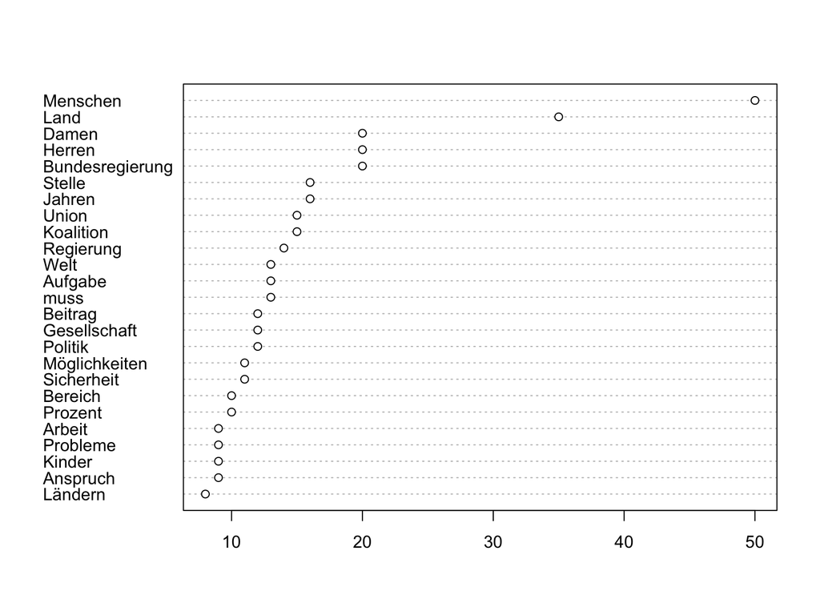

```r
dotplot(nouns, col = "count", n = 25)
```

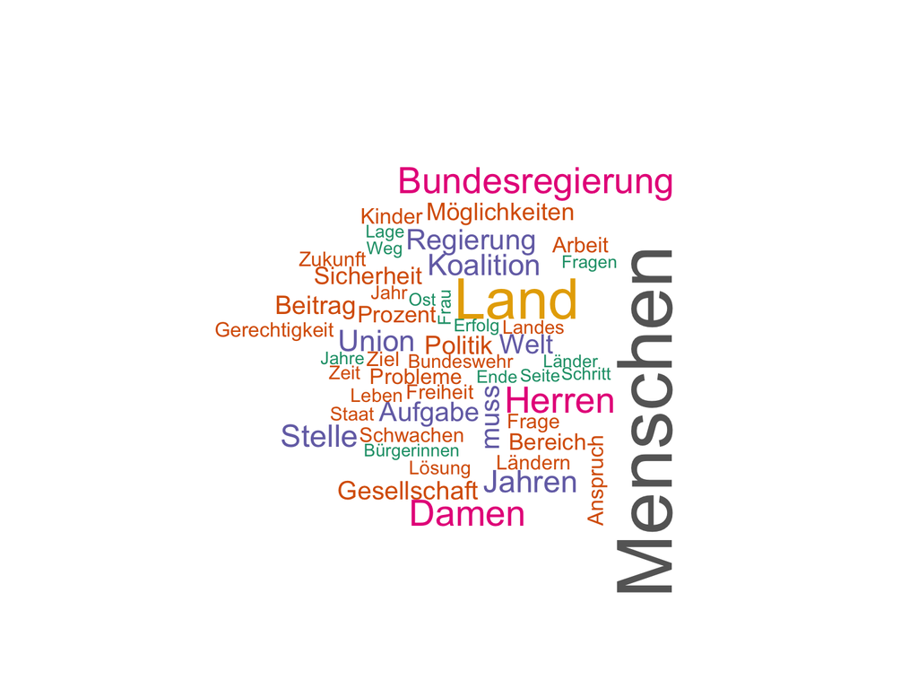

```r
library(wordcloud)
wordcloud(
  words = nouns@stat[["word"]][1:50],
  freq = nouns@stat[["count"]][1:50]/2,
  colors = brewer.pal(8,"Dark2")
  )
```

## Anlegen von Partition

### Eine wichtige Unterscheidung

- s-Attribute (parameter sAttributes)
- p-Attribute (parameter pAttributes)

### Exploration eines Korpus

Finden verfügbarer p-Attribute

```r
pAttributes("GERMAPARL")
```

```
## [1] "lemma" "pos"   "word"
```

Finden verfügbarer s-Attribute

```r
sAttributes("GERMAPARL")
```

Finden der Ausprägungen eines s-Attributes

```r
speakers <- sAttributes("GERMAPARL", "speaker")
head(speakers)
```

```
## [1] "Rita Süssmuth"    "Günter Rexrodt"   "Rudolf Scharping"
## [4] "Michael Glos"     "Antje Vollmer"    "Joschka Fischer"
```

#### Partitionierung

```r
schroeder <- partition("GERMAPARL", speaker = "Gerhard Schröder")
bk <- partition("GERMAPARL", speaker = c("Gerhard Schröder", "Angela Merkel"))
bk <- partition("GERMAPARL", speaker = c("Gerhard Schröder", "Angela Merkel"), lp=c("14", "15", "16"))
```

## Kurzeinführung in die Welt der regulären Ausdrücke

** Zeichenklassen: ** . beliebiges Zeichen \d Zahl

** Quantoren ** + mindestens einmal * keinmal oder beliebig oft {} bestimmte Anzahl

** Sonstiges ** Alternativen in Klammern alternative Zeichen in eckigen Klammern

```r
schroederPost911 <- partition(
  "GERMAPARL", speaker = "Gerhard Schröder",
  date = c("2001-(09|10|11|12)-.*"), regex=TRUE
  )
sAttributes(schroederPost911, "date")
```

## Partitionen bündeln!

```r
schroeder <- partitionBundle(
  schroederPost911,
  sAttribute = sAttributes(schroederPost911, "date"),
  type = "plpr"
)
summary(schroeder)
read(schroeder, meta="speaker_date")
label(schroeder, meta="speaker_date")
1read(schroeder[[8]], meta="speaker_date")
```

## Ein fortgeschrittenes Szenario

```r
library(chron)
library(magrittr)
days <- sAttributes("GERMAPARL", "date")
aftermath <- seq.dates(from = "11/09/2001", "11/03/2002", by = "days") %>%
  as.Date(format="%Y-%m-%d") %>%
  as.character
sessionsAftermath <- days[days %in% aftermath]
foo <- partition("GERMAPARL", date =sessionsAftermath, pAttribute="word")
view(foo)
```

Einige weitere Möglichkeiten

[output not shown]

```r
foo <- frequencies(bt, query='"[mM]ultikult.*"', pAttribute=NULL)
```

Übung: Parteienunterschiede …

```r
csu <- partition(list(speaker_party=".*CSU.*"), regex=TRUE)
```

# Konkordanzen

```r
kwic(bt, '"Krieg" "gegen" "den" "Terror"', meta=c("speaker_date"))
kwic(bt, '"Krieg" "gegen" "den" "Terror"', meta=c("speaker_date", "speaker_name"))
```

```r
foo <- frequencies(bt, '"()"')

Bkwic(bt, '"Krieg" "gegen" []{0,1} [pos="NN"]', meta=c("speaker_date", "speaker_party"))
```

Inspektion der Hilfe …

#### Kollokationsanalysen

```r
bt <- partition("BT", list(speaker_year="2006"), regex=TRUE)
islam <- context(bt, "Islam", pAttribute="word")
islam <- context(bt, '"Islam.*"', pAttribute=c("word", "pos"))
view(islam)
islam2 <- subset(islam, pos %in% c("NN", "ADJA"))
view(islam2)
wordcloud(
  words=islam2@stat[["word"]][1:50],
  freq=islam2@stat[["ll"]][1:50]/2,
  colors=brewer.pal(8,"Dark2")
  )
dotplot(islam2, col="ll", 25)
```

weiterführend: Als Testverfahren implementiert t-test, PMI, log-likelihood

** Diskussion: ** Welche Filter sind angemessen? Welche Schwellenwerte sind angemessen? Welcher Kontext ist bei politikwissenschaftlichen Fragestellungen angemessen?

#### Schlagwortanalysen

Was nicht funktioniert …

```r
schroeder1 <- partition("GERMAPARL", speaker = "Gerhard Schröder", date = "2001-09-12", pAttribute = "word")
schroeder2 <- partition("GERMAPARL", speaker = "Gerhard Schröder", date="2001-09-19", pAttribute = "word")
schroeder3 <- partition("GERMAPARL", speaker = "Gerhard Schröder", date="2001-11-28", pAttribute = "word")

bt2001 <- partition("GERMAPARL", year = "2001", pAttribute = "word")

keyws1 <- features(schroeder1, bt2001)
keyws2 <- features(schroeder2, bt2001)
keyws3 <- features(schroeder3, bt2001)

view(keyws1)
view(keyws2)
view(keyws3)
```

Mehr ist besser …

```r
bt2002 <- partition("GERMAPARL", year = "2002", interjection = FALSE, pAttribute="word")
btBefore <- partition("GERMAPARL", year = 1996:2001, interjection = FALSE, pAttribute = "word")

keyws <- features(bt2002, btBefore)
view(keyws)
```

Übung: Themenschwerpunkte von Schröder in der 15. Legislaturperiode?

# Perspektiven der Textstatistik

```r
merkel <- partition("BT", list(speaker_name=".*Merkel.*", speaker_type="speech"), regex=TRUE, pAttribute="word")
merkelSpeeches <- as.speeches(
  merkel, sAttributeDates="speaker_date", sAttributeNames="speaker_name",
  gap=500
  )
merkelSpeeches <- enrich(merkelSpeeches, pAttribute="word")
dtm <- as.DocumentTermMatrix(merkelSpeeches, col="count")
toDrop <- polmineR:::noise(dtm)
dtmTrimmed <- trim(dtm, termsToDrop=unique(unlist(toDrop)))
dtmTrimmed <- trim(dtmTrimmed, docsToDrop = names(which(slam::row_sums(dtmTrimmed) < 20)))

library(topicmodels)
tmodel <- LDA(
  dtmTrimmed, k=20, method = "Gibbs",
  control = list(burnin = 1000, iter = 50, keep = 50, verbose=TRUE)
)
View(terms(tmodel, k=20))
```

### Was passiert da eigentlich?!

- S4-Klassen und ihre Slots (Strukturanalyse mit str())
- Vererbung von Methoden, weniger zu merken

```r
str(nounsOnly)
methods("partition"")
getMethod("subset", "textstat")
```

## Ausblick: Alternativen

- Perl (reguläre Ausdrücke etc.)
- Python (NLTK, etc.)
- Java (Stanford NLP, mallet etc.)
- C++ (Performanz)